# Desindustrialización y especialización exportadora: la trayectoria argentina en perspectiva comparada (1970-2024)

Trabajo integrador final. Diplomatura en Programación en R Aplicada a la Economía, FCE-UBA

Autor

Alvaro Miguel Ocampo

Fecha

1 de octubre de 2026

# Resumen ejecutivo

Este informe examina si la trayectoria industrial argentina de las últimas cinco décadas encaja en lo que la literatura llama desindustrialización fallida, y cómo se refleja en su perfil exportador. Combina la serie de PIB industrial a precios constantes de Argendata (Fundar), basada en cuentas nacionales de la ONU, con la base de comercio BACI (CEPII) para 2024, y compara nueve países de tres regiones.

Entre 1970 y 2023 la participación argentina en el PIB industrial mundial cayó de 1,6 a 0,6 por ciento, una pérdida relativa que comparten Francia, el Reino Unido o Japón. Lo distintivo del caso argentino es el estancamiento absoluto: el PIB industrial por habitante de 2023 es igual al de 1970. En el plano comercial, Argentina exporta con ventaja comparativa un conjunto reducido de bienes, casi todos primarios o agroindustriales, con la menor diversidad y la mayor concentración de la muestra. Ambas dimensiones describen una industria que dejó de crecer y una inserción externa que ninguna especialización nueva reemplazó.

# 1 Introducción

La caída del empleo industrial en el empleo total atraviesa a casi todos los países desde los años setenta, pero detrás de ese rasgo común conviven procesos distintos. En algunos casos la industria siguió expandiendo su producción mientras cedía empleo a los servicios; en otros la contracción fue también absoluta y arrastró al conjunto de la economía. Argentina suele presentarse como ejemplo de lo segundo, y este trabajo contrasta esa caracterización con datos comparables.

La pregunta es doble: qué distingue el recorrido industrial argentino del de otros países que también perdieron peso en la manufactura mundial, y cómo se expresa ese recorrido en la canasta exportadora actual. La hipótesis, apoyada en Herrera Bartis (2021), es que la particularidad argentina está en la dimensión absoluta del fenómeno y que esa debilidad se traduce en una especialización comercial estrecha, concentrada en bienes de bajo contenido de conocimiento.

Se construyen tres indicadores. La participación en el PIB industrial mundial y el PIB industrial per cápita, para 1970-2023, separan la pérdida de importancia relativa de la destrucción efectiva de capacidad productiva. Las ventajas comparativas reveladas para 2024 se leen junto con la diversidad de cada país y la ubicuidad de los productos en que se especializa.

# 2 Desarrollo conceptual

## 2.1 De la madurez a la nueva división internacional del trabajo

El término desindustrialización nació en el debate sobre Estados Unidos y Gran Bretaña en los años setenta y, en sentido estrecho, designa la caída de la participación del empleo manufacturero en el empleo total. Como recuerda Herrera Bartis (2021), el uso se amplió hasta abarcar la contracción de la producción, el cierre de establecimientos y los desequilibrios comerciales. Más relevante que la definición es la interpretación: para una parte de la literatura es un subproducto normal de la madurez económica, explicado por la mayor productividad de la industria y la menor elasticidad ingreso de la demanda de manufacturas; para otra, un fenómeno nocivo que refleja la incapacidad del sector para sostenerse.

La taxonomía de Rowthorn que Herrera Bartis recupera ordena esa discusión en tres tipos. En la desindustrialización por madurez el empleo industrial relativo cae sin que se interrumpa el crecimiento del producto industrial ni del agregado. En la desindustrialización por reespecialización la industria se estanca, pero otra actividad, típicamente de servicios transables, sostiene la expansión del conjunto. En la desindustrialización fallida o negativa la contracción industrial es también absoluta y se extiende al resto de la economía, con más desempleo y precariedad y presión sobre las cuentas externas. Estados Unidos, el Reino Unido y Argentina ilustran cada tipo. Para Argentina el autor identifica un quiebre a mediados de los setenta, una caída del valor agregado industrial por habitante cercana al 45 por ciento entre 1974 y 1990 y una primarización de la estructura manufacturera.

La noción de desindustrialización prematura, posterior, aplica la idea de desindustrialización negativa a economías que iniciaron el proceso con ingresos por habitante mucho menores que los de los países centrales. Graña y Terranova (2022) critican esa distinción: el adjetivo presupone un momento correcto para desindustrializarse, y el ingreso al que comienza el proceso viene cayendo en el tiempo, de modo que Corea del Sur o Taiwán también deberían contarse como prematuros. Su explicación es que desde los setenta la nueva división internacional del trabajo (NDIT) hizo de la desindustrialización un fenómeno global y simultáneo: las telecomunicaciones y la automatización flexible permitieron deslocalizar las fases más simples de la producción hacia países de bajos salarios, primero del este asiático y luego China y el sudeste asiático. “Algunos países desindustrializan a otros”: entre 1970 y 1985 los salarios industriales de Corea y Taiwán eran el 56 por ciento de los latinoamericanos, lo que explica por qué la relocalización no vino a América Latina. Dos consecuencias importan aquí. El PIB industrial agregado de su muestra no declina, de modo que lo que hubo fue una migración geográfica de la industria y no una desindustrialización mundial. Y a precios constantes ningún país de su muestra registra una caída absoluta del valor agregado manufacturero, con lo cual el calificativo de “negativa” depende de la fuente, el período y la unidad de medida.

## 2.2 Cómo se mide

De esa discusión surgen tres familias de indicadores. La participación del empleo industrial captura el sentido estrecho del fenómeno. La participación del valor agregado industrial en el total nacional o mundial informa sobre el peso relativo del sector. La evolución absoluta del producto industrial, en especial por habitante, es la que permite distinguir una pérdida de importancia relativa de una destrucción de capacidad, el criterio que separa a la desindustrialización fallida de las otras dos variantes.

La elección entre valores corrientes y constantes no es neutra. Graña y Terranova usan precios corrientes para medir la relevancia económica de la industria, porque incorporan los precios relativos, y advierten que una estructura de precios fija de un año base sesga las tendencias de muy largo plazo. Para medir capacidad productiva lo pertinente es el volumen, es decir, precios constantes, como hacen Herrera Bartis y la serie empleada aquí. Se suma la moneda de comparación: el tipo de cambio nominal es volátil y refleja movimientos financieros y políticas cambiarias antes que productividad, por lo que puede hacer aparecer o desaparecer una desindustrialización según el momento del ciclo cambiario. Las series en paridad de poder adquisitivo atenúan ese problema a costa de otros supuestos.

## 2.3 Ventajas comparativas, diversidad y ubicuidad

El indicador de ventajas comparativas reveladas (VCR) de Balassa compara la participación de un producto en las exportaciones de un país con su participación en las exportaciones mundiales; un valor mayor a uno indica una especialización relativa mayor que la del mundo y, por ser relativo, filtra el tamaño del país. Sobre esa base, la complejidad económica define la diversidad de un país como la cantidad de productos que exporta con VCR, y la ubicuidad de un producto como la cantidad de países que lo exportan con VCR (Fumeo y Terranova, 2023): los bienes que requieren capacidades sofisticadas son exportados por pocos países.

Fernández Franco, Paola, Terranova y Weksler (2025) señalan varias limitaciones. La lectura habitual es dicotómica, así que un coeficiente de 1,1 y uno de 40 reciben la misma clasificación. Un país con especialización primaria muy marcada difícilmente muestre ventajas en rubros industriales aunque los exporte en montos relevantes. Las exportaciones brutas no distinguen qué parte del valor se produjo en el país, lo que sobreestima a las plataformas de ensamblaje. Y la ubicuidad puede ser baja por rareza del recurso y no por sofisticación, como señalan para el petróleo. Los autores recomiendan complementar la lectura relativa con medidas absolutas, que es lo que se hace aquí al cruzar comercio con producción.

# 3 Metodología

La serie de PIB industrial proviene de Argendata (Fundar) y cubre 220 países entre 1970 y 2023. Según la documentación del portal, corresponde al valor agregado de la industria manufacturera a precios constantes de 2015 en dólares, elaborado sobre la base National Accounts, Analysis of Main Aggregates de la División de Estadística de la ONU. La población se tomó de la misma fuente; como identifica los países por nombre en inglés y Fundar por código ISO3, hizo falta un diccionario para unirlas.

La selección de países sigue la sugerida en el módulo 3 y es compatible con los grupos de Graña y Terranova: Argentina, Brasil y México; Estados Unidos, Francia y Reino Unido; Japón, Corea del Sur y China. Los agregados regionales son la suma de los tres países de cada grupo, no de la región completa. Los resultados se leen como medidas de volumen, no de relevancia económica corriente.

Los datos de comercio provienen de BACI (CEPII), nomenclatura HS22, versión 202601, para 2024: flujos bilaterales a seis dígitos del Sistema Armonizado para 226 exportadores y 5.606 productos, en miles de dólares corrientes. Como el archivo completo supera los 350 megabytes y no cabe en el repositorio, se lo procesó previamente en R: se agregaron las exportaciones por país y producto, se calcularon los totales por país, por producto y mundiales, y se guardaron en `bases/` dos archivos reducidos, las exportaciones por producto de los nueve países y la ubicuidad de cada producto, calculada sobre todos los exportadores. Las VCR se calculan con la fórmula de Balassa sin suavizado, ya que hay un solo año.

Los productos se agrupan por capítulos del Sistema Armonizado en once rubros. Es un agrupamiento propio, más grueso que la clasificación por contenido tecnológico de Lall (2000), definida sobre la nomenclatura CUCI y sin tabla de correspondencia disponible. Las VCR por rubro se calculan sobre los agregados de cada rubro, y la diversidad como la cantidad de productos a seis dígitos con coeficiente mayor a uno. El ejercicio comercial ofrece una fotografía de 2024 y no una evolución; se lo interpreta como la expresión actual de un proceso cuya dinámica se lee en las series de producción.

**Lectura de las bases y armado de los indicadores de producción**

```r
pib <- read_csv("bases/pib_industrial_mundial.csv", show_col_types = FALSE)
poblacion <- read_csv("bases/poblacion.csv", show_col_types = FALSE)

seleccion <- tibble(
  iso3 = c("ARG", "BRA", "MEX", "USA", "FRA", "GBR", "JPN", "KOR", "CHN"),
  pais = c("Argentina", "Brasil", "México", "Estados Unidos", "Francia",
           "Reino Unido", "Japón", "Corea del Sur", "China"),
  nombre_onu = c("Argentina", "Brazil", "Mexico", "United States", "France",
                 "United Kingdom of Great Britain and Northern Ireland",
                 "Japan", "Republic of Korea", "China (mainland)"),
  region = rep(c("América Latina", "Desarrollados tradicionales", "Este asiático"), each = 3)
)

pib_mundial <- pib %>%
  group_by(anio) %>%
  summarise(pib_mundo = sum(industry_gdp, na.rm = TRUE))

participacion <- pib %>%
  inner_join(seleccion, by = c("geocodigoFundar" = "iso3")) %>%
  left_join(pib_mundial, by = "anio") %>%
  mutate(participacion = industry_gdp / pib_mundo * 100)

poblacion <- poblacion %>%
  rename(nombre_onu = `Country/Area`, anio = Year) %>%
  filter(Unit == "Persons", nombre_onu %in% seleccion$nombre_onu) %>%
  mutate(anio = as.numeric(anio), poblacion = as.numeric(Population)) %>%
  inner_join(seleccion, by = "nombre_onu") %>%
  select(iso3, anio, poblacion)

per_capita <- participacion %>%
  inner_join(poblacion, by = c("geocodigoFundar" = "iso3", "anio")) %>%
  mutate(pib_pc = industry_gdp / poblacion) %>%
  group_by(pais) %>%
  mutate(indice = pib_pc / pib_pc[anio == 1970] * 100) %>%
  ungroup()
```

**Lectura de las bases de comercio y cálculo de las ventajas comparativas**

```r
expo <- read_csv("bases/expo_2024_paises.csv", col_types = cols(producto = col_character()))
ubicuidad <- read_csv("bases/ubicuidad_2024.csv", col_types = cols(producto = col_character()))

rubros <- c("Primarios agropecuarios", "Alimentos, bebidas y tabaco",
            "Minerales y combustibles", "Cueros, madera y papel",
            "Textiles, indumentaria y calzado", "Químicos, plásticos y caucho",
            "Minerales no metálicos y piedras preciosas", "Metales y sus manufacturas",
            "Maquinaria y equipo eléctrico", "Material de transporte",
            "Instrumentos y otras manufacturas")

expo <- expo %>%
  mutate(vcr = (valor / expo_pais) / (expo_producto / expo_mundo),
         capitulo = as.integer(substr(producto, 1, 2)),
         rubro = case_when(capitulo <= 15 ~ rubros[1],
                           capitulo <= 24 ~ rubros[2],
                           capitulo <= 27 ~ rubros[3],
                           capitulo <= 40 ~ rubros[6],
                           capitulo <= 49 ~ rubros[4],
                           capitulo <= 67 ~ rubros[5],
                           capitulo <= 71 ~ rubros[7],
                           capitulo <= 83 ~ rubros[8],
                           capitulo <= 85 ~ rubros[9],
                           capitulo <= 89 ~ rubros[10],
                           TRUE ~ rubros[11]),
         rubro = factor(rubro, levels = rubros)) %>%
  left_join(ubicuidad, by = "producto") %>%
  rename(iso3 = pais) %>%
  left_join(seleccion %>% select(iso3, pais), by = "iso3")

# ventajas comparativas por rubro: se recalculan sobre los agregados de cada rubro
mundo_rubro <- expo %>%
  distinct(producto, rubro, expo_producto, expo_mundo) %>%
  group_by(rubro) %>%
  summarise(expo_rubro_mundo = sum(expo_producto), expo_mundo = first(expo_mundo))

vcr_rubro <- expo %>%
  group_by(pais, rubro) %>%
  summarise(valor = sum(valor), expo_pais = first(expo_pais), .groups = "drop") %>%
  left_join(mundo_rubro, by = "rubro") %>%
  mutate(participacion = valor / expo_pais * 100,
         vcr = (valor / expo_pais) / (expo_rubro_mundo / expo_mundo))

diversidad <- expo %>%
  group_by(pais) %>%
  summarise(exportaciones = first(expo_pais) / 1e6,
            productos = n(),
            con_vcr = sum(vcr > 1),
            concentracion = sum(valor[vcr > 1]) / first(expo_pais) * 100,
            ubicuidad_mediana = median(ubicuidad[vcr > 1])) %>%
  arrange(desc(con_vcr))
```

# 4 Resultados y análisis

## 4.1 La migración de la industria: participación en el PIB industrial mundial

Entre 1970 y 2023 el PIB industrial mundial a precios constantes se multiplicó por 5,3. No hubo una desindustrialización del mundo sino una relocalización de la producción, como sostienen Graña y Terranova. La Tabla 1 muestra cómo se repartió esa expansión.

**Ver código**

```r
anios_tabla <- c(1970, 1980, 1990, 2000, 2010, 2023)

tabla_paises <- participacion %>%
  filter(anio %in% anios_tabla) %>%
  select(region, pais, anio, participacion)

tabla_regiones <- tabla_paises %>%
  group_by(region, anio) %>%
  summarise(participacion = sum(participacion), .groups = "drop") %>%
  mutate(pais = paste("Total", region))

bind_rows(tabla_paises, tabla_regiones) %>%
  mutate(region = factor(region, levels = unique(seleccion$region)),
         orden = if_else(str_starts(pais, "Total"), 2, 1)) %>%
  arrange(region, orden, pais) %>%
  mutate(participacion = num(participacion, 2)) %>%
  pivot_wider(id_cols = c(region, pais), names_from = anio, values_from = participacion) %>%
  rename(Región = region, País = pais) %>%
  kable(align = c("l", "l", rep("r", 6)))
```

Tabla 1: Participación en el PIB industrial mundial, años seleccionados (en porcentaje)

| Región | País | 1970 | 1980 | 1990 | 2000 | 2010 | 2023 |
| --- | --- | --- | --- | --- | --- | --- | --- |
| América Latina | Argentina | 1,59 | 1,32 | 0,77 | 0,86 | 0,89 | 0,57 |
| América Latina | Brasil | 2,01 | 3,45 | 2,53 | 2,24 | 2,08 | 1,20 |
| América Latina | México | 2,01 | 2,83 | 2,49 | 2,91 | 2,05 | 1,79 |
| América Latina | Total América Latina | 5,61 | 7,60 | 5,80 | 6,01 | 5,02 | 3,56 |
| Desarrollados tradicionales | Estados Unidos | 27,51 | 22,92 | 20,94 | 24,06 | 19,81 | 15,29 |
| Desarrollados tradicionales | Francia | 4,20 | 3,80 | 3,13 | 3,17 | 2,36 | 1,77 |
| Desarrollados tradicionales | Reino Unido | 4,80 | 3,84 | 3,30 | 3,02 | 2,40 | 1,87 |
| Desarrollados tradicionales | Total Desarrollados tradicionales | 36,51 | 30,55 | 27,37 | 30,26 | 24,57 | 18,93 |
| Este asiático | China | 1,03 | 1,77 | 3,13 | 8,91 | 20,40 | 31,89 |
| Este asiático | Corea del Sur | 0,20 | 0,63 | 1,45 | 2,77 | 3,61 | 3,40 |
| Este asiático | Japón | 10,23 | 11,14 | 12,71 | 10,79 | 8,62 | 6,58 |
| Este asiático | Total Este asiático | 11,46 | 13,54 | 17,30 | 22,47 | 32,64 | 41,88 |

Los tres países desarrollados pasaron del 36,5 al 18,9 por ciento del PIB industrial mundial, y los tres asiáticos recorrieron el camino inverso, del 11,5 al 41,9 por ciento. Dentro de Asia las trayectorias difieren: Japón alcanza su máximo hacia 1990 y desde entonces pierde la mitad de su participación, Corea crece hasta 2010 y se estabiliza, y China pasa de un peso marginal a casi un tercio del total. Es la secuencia de “olas” que describen Graña y Terranova, en la que cada nuevo destino de la deslocalización desplaza al anterior a medida que suben sus salarios.

América Latina queda al margen. Los tres países del grupo pasan del 5,6 al 3,6 por ciento, con un pico transitorio a comienzos de los ochenta. Argentina es el caso más pronunciado: cae de 1,59 a 0,57 por ciento, poco más de un tercio del valor inicial. En este indicador, sin embargo, la pérdida argentina no difiere cualitativamente de la de Francia o el Reino Unido, que también ceden más de la mitad de su participación. La Figura 1 muestra que el gran reparto se da entre los desarrollados y Asia, con los latinoamericanos como espectadores.

**Ver código**

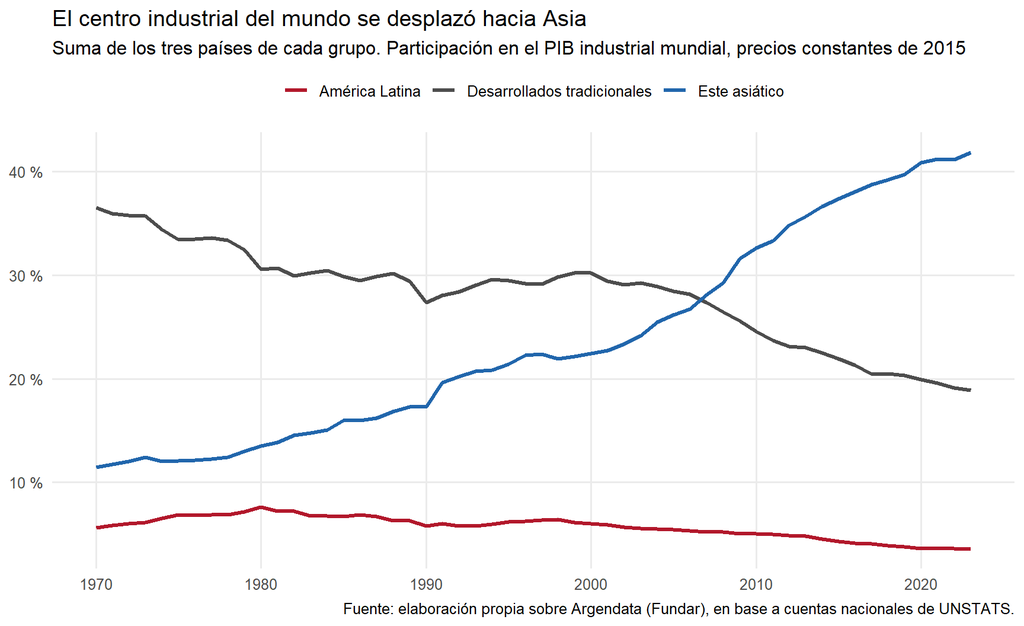

Figura 1: Participación en el PIB industrial mundial por grupo de países, 1970-2023

```r
dir.create("graficos", showWarnings = FALSE)

g_participacion <- reg %>%
  ggplot(aes(x = anio, y = participacion, colour = region)) +
  geom_line(linewidth = 1.1) +
  scale_x_continuous(breaks = seq(1970, 2020, 10)) +
  scale_y_continuous(labels = label_number(suffix = " %", decimal.mark = ",")) +
  scale_colour_manual(values = c("América Latina" = "#b2182b",
                                 "Desarrollados tradicionales" = "#4d4d4d",
                                 "Este asiático" = "#2166ac")) +
  labs(title = "El centro industrial del mundo se desplazó hacia Asia",
       subtitle = "Suma de los tres países de cada grupo. Participación en el PIB industrial mundial, precios constantes de 2015",
       x = NULL, y = NULL, colour = NULL,
       caption = "Fuente: elaboración propia sobre Argendata (Fundar), en base a cuentas nacionales de UNSTATS.") +
  theme_minimal(base_size = 12) +
  theme(legend.position = "top", panel.grid.minor = element_blank())

g_participacion
ggsave("graficos/01_participacion_pib_industrial.png", g_participacion, width = 9, height = 5.5, dpi = 300)
```

## 4.2 Pérdida relativa o retroceso absoluto: el PIB industrial por habitante

La participación mundial no distingue entre una industria que crece menos que las demás y una que dejó de crecer. Para eso hace falta una medida absoluta, y el PIB industrial por habitante es la que usa Herrera Bartis para contrastar las hipótesis de Rowthorn. La Figura 2 presenta el índice base 1970 en escala logarítmica, de modo que pendientes iguales son tasas de crecimiento iguales.

**Ver código**

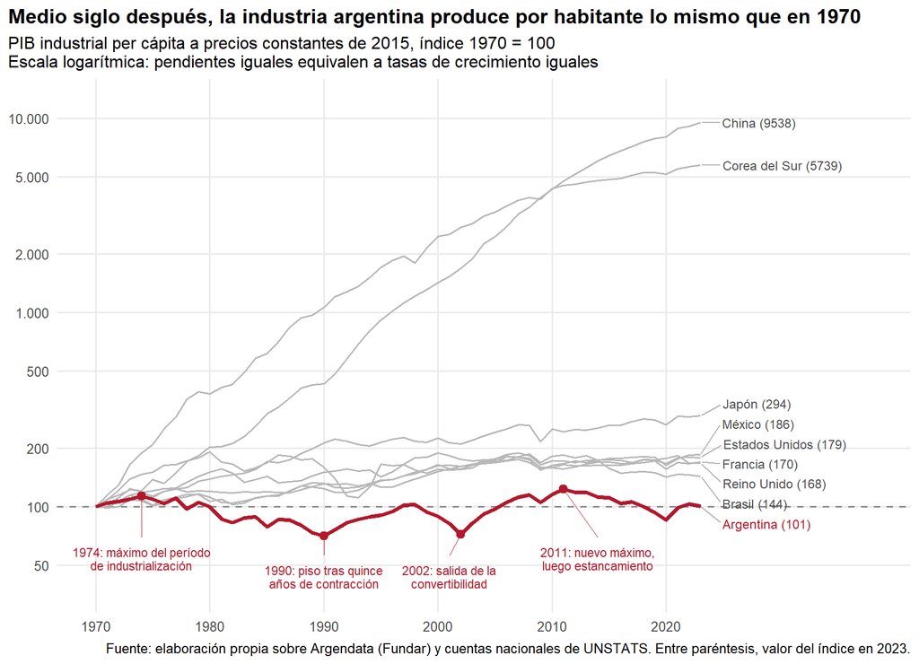

Figura 2: PIB industrial per cápita, índice 1970 = 100 (escala logarítmica)

```r
etiquetas_fin <- per_capita %>%
  filter(anio == 2023) %>%
  mutate(etiqueta = paste0(pais, " (", round(indice), ")"))

hitos <- arg %>%
  filter(anio %in% c(1974, 1990, 2002, 2011)) %>%
  mutate(texto = c("1974: máximo del período\nde industrialización",
                   "1990: piso tras quince\naños de contracción",
                   "2002: salida de la\nconvertibilidad",
                   "2011: nuevo máximo,\nluego estancamiento"),
         y_texto = c(62, 50, 50, 62),
         x_texto = c(1974, 1990, 2001, 2014))

g_per_capita <- per_capita %>%
  ggplot(aes(x = anio, y = indice, group = pais)) +
  geom_hline(yintercept = 100, colour = "grey55", linetype = "dashed") +
  geom_line(data = ~ filter(.x, pais != "Argentina"), colour = "grey72", linewidth = 0.7) +
  geom_line(data = ~ filter(.x, pais == "Argentina"), colour = "#b2182b", linewidth = 1.4) +
  geom_segment(data = hitos, aes(xend = x_texto, yend = y_texto * 1.12), colour = "#b2182b", linewidth = 0.3) +
  geom_point(data = hitos, colour = "#b2182b", size = 2.5) +
  geom_text(data = hitos, aes(x = x_texto, y = y_texto, label = texto), size = 3, colour = "#b2182b",
            lineheight = 0.9, vjust = 1) +
  geom_text_repel(data = etiquetas_fin, aes(label = etiqueta),
                  nudge_x = 2, direction = "y", hjust = 0, size = 3.2, segment.colour = "grey70",
                  colour = if_else(etiquetas_fin$pais == "Argentina", "#b2182b", "grey30")) +
  scale_x_continuous(breaks = seq(1970, 2020, 10), limits = c(1970, 2038)) +
  scale_y_log10(breaks = c(50, 100, 200, 500, 1000, 2000, 5000, 10000),
                limits = c(38, 12000),
                labels = label_number(big.mark = ".", decimal.mark = ",")) +
  labs(title = "Medio siglo después, la industria argentina produce por habitante lo mismo que en 1970",
       subtitle = "PIB industrial per cápita a precios constantes de 2015, índice 1970 = 100\nEscala logarítmica: pendientes iguales equivalen a tasas de crecimiento iguales",
       x = NULL, y = NULL,
       caption = "Fuente: elaboración propia sobre Argendata (Fundar) y cuentas nacionales de UNSTATS. Entre paréntesis, valor del índice en 2023.") +
  theme_minimal(base_size = 12) +
  theme(panel.grid.minor = element_blank(),
        plot.title = element_text(face = "bold"),
        plot.title.position = "plot")

g_per_capita
ggsave("graficos/02_pib_industrial_per_capita.png", g_per_capita, width = 9, height = 6.5, dpi = 300)
```

El contraste es nítido. En 2023 todos los países producían más bienes industriales por habitante que en 1970, desde el 144 de Brasil hasta 5.739 en Corea y 9.538 en China. Argentina es la excepción, con un índice de 101: fabrica hoy por habitante lo mismo que hace cincuenta y tres años, mientras Estados Unidos, Francia y el Reino Unido, que también perdieron peso relativo, aumentaron su producción por habitante entre un 68 y un 79 por ciento.

La trayectoria argentina reproduce la periodización de Herrera Bartis. El PIB industrial por habitante alcanza un máximo en 1974, con 2.148 dólares, y cae a 1.331 en 1990, una contracción del 38 por ciento que coincide en sentido, no en magnitud exacta, con el 45 por ciento que el autor estima con otras fuentes. La convertibilidad dibuja una U invertida que termina en 2002 apenas por encima de 1990. La recuperación posterior lleva la serie a un nuevo máximo en 2011, de 2.325 dólares, pero desde entonces la tendencia es descendente y 2023 cierra en 1.901 dólares, por debajo de 1974. Lo que distingue a Argentina no es haber perdido participación, sino haber atravesado dos ciclos de contracción absoluta de los que nunca terminó de salir, el rasgo que define a la desindustrialización fallida.

Conviene señalar una discrepancia con la bibliografía. Herrera Bartis describe para el Reino Unido un estancamiento del producto industrial por habitante entre 1973 y 2010, mientras que la serie de UNSTATS a precios de 2015 muestra un crecimiento del 68 por ciento entre 1970 y 2023. La diferencia obedece a la fuente, el deflactor y el año base, e ilustra la advertencia de Graña y Terranova sobre las series a precios constantes en comparaciones de muy largo plazo: no conviene sobreinterpretar diferencias entre países cuyo índice se ubica entre 150 y 200.

## 4.3 La expresión comercial: ventajas comparativas, diversidad y ubicuidad

La Tabla 2 resume, para 2024, cuántos productos exporta cada país, en cuántos tiene VCR, qué proporción de sus exportaciones se concentra en ellos y cuál es la ubicuidad mediana de esa canasta.

**Ver código**

```r
diversidad %>%
  transmute(País = pais,
            `Exportaciones (miles de millones de USD)` = num(exportaciones, 0),
            `Productos exportados` = num(productos, 0),
            `Productos con VCR > 1` = num(con_vcr, 0),
            `Exportaciones en productos con VCR (%)` = num(concentracion, 1),
            `Ubicuidad mediana de los productos con VCR` = num(ubicuidad_mediana, 0)) %>%
  kable(align = c("l", rep("r", 5)))
```

Tabla 2: Diversidad y concentración de la canasta exportadora, 2024

| País | Exportaciones (miles de millones de USD) | Productos exportados | Productos con VCR > 1 | Exportaciones en productos con VCR (%) | Ubicuidad mediana de los productos con VCR |
| --- | --- | --- | --- | --- | --- |
| China | 3.606 | 5.566 | 2.742 | 81,3 | 15 |
| Francia | 636 | 5.569 | 1.972 | 77,4 | 19 |
| Estados Unidos | 1.898 | 5.596 | 1.616 | 74,3 | 17 |
| Reino Unido | 424 | 5.489 | 1.503 | 70,8 | 19 |
| Japón | 731 | 5.389 | 1.411 | 84,0 | 15 |
| Corea del Sur | 721 | 5.220 | 902 | 84,2 | 15 |
| México | 650 | 4.929 | 737 | 81,5 | 21 |
| Brasil | 350 | 5.129 | 535 | 83,4 | 19 |
| Argentina | 80 | 3.976 | 466 | 91,2 | 21 |

Argentina exporta 3.976 de los 5.606 productos de la nomenclatura, pero tiene VCR en sólo 466, la menor diversidad de los nueve países y una sexta parte de la de China. A la vez, el 91,2 por ciento de sus ventas externas corresponde a esos productos, la concentración más alta de la muestra. Brasil y México siguen en diversidad, con canastas más repartidas. La ubicuidad mediana no ordena a los países con la misma claridad: los asiáticos se especializan en productos que exportan con ventaja unos 15 países, Argentina y México en productos exportados por 21, y los desarrollados quedan en el medio. Es una de las limitaciones que señalan Fernández Franco y coautores: la ubicuidad mezcla sofisticación con rareza. En la canasta argentina los porotos de soja resultan menos ubicuos que las camionetas, y el oro o el petróleo crudo, que muchos países exportan con ventaja, figuran entre los productos más ubicuos.

**Ver código**

```r
vcr_rubro %>%
  select(pais, rubro, vcr) %>%
  mutate(vcr = num(vcr, 2)) %>%
  pivot_wider(names_from = pais, values_from = vcr) %>%
  left_join(vcr_rubro %>% filter(pais == "Argentina") %>% select(rubro, participacion), by = "rubro") %>%
  mutate(Rubro = paste0(rubro, " (", num(participacion, 1), ")")) %>%
  select(Rubro, all_of(seleccion$pais)) %>%
  kable(align = c("l", rep("r", 9)))
```

Tabla 3: Ventajas comparativas reveladas por rubro del Sistema Armonizado, 2024. Entre paréntesis, participación del rubro en las exportaciones de Argentina (%)

| Rubro | Argentina | Brasil | México | Estados Unidos | Francia | Reino Unido | Japón | Corea del Sur | China |
| --- | --- | --- | --- | --- | --- | --- | --- | --- | --- |
| Primarios agropecuarios (40,0) | 7,00 | 4,89 | 0,82 | 1,08 | 1,09 | 0,45 | 0,09 | 0,08 | 0,25 |
| Alimentos, bebidas y tabaco (18,1) | 4,85 | 3,43 | 1,14 | 0,86 | 2,05 | 1,35 | 0,18 | 0,34 | 0,32 |
| Minerales y combustibles (11,5) | 0,77 | 1,84 | 0,42 | 1,28 | 0,32 | 0,61 | 0,11 | 0,52 | 0,10 |
| Cueros, madera y papel (1,5) | 0,62 | 2,28 | 0,28 | 0,88 | 1,73 | 0,77 | 0,25 | 0,25 | 1,01 |
| Textiles, indumentaria y calzado (0,5) | 0,12 | 0,46 | 0,27 | 0,29 | 0,74 | 0,42 | 0,25 | 0,33 | 2,09 |
| Químicos, plásticos y caucho (8,3) | 0,58 | 0,37 | 0,35 | 1,26 | 1,58 | 1,18 | 1,05 | 1,09 | 0,76 |
| Minerales no metálicos y piedras preciosas (4,7) | 0,94 | 0,38 | 0,54 | 0,70 | 0,84 | 1,55 | 0,92 | 0,27 | 0,52 |
| Metales y sus manufacturas (2,8) | 0,41 | 0,80 | 0,53 | 0,67 | 0,95 | 0,92 | 1,30 | 1,09 | 1,16 |
| Maquinaria y equipo eléctrico (1,7) | 0,06 | 0,19 | 1,38 | 0,88 | 0,70 | 0,94 | 1,34 | 1,64 | 1,74 |
| Material de transporte (10,6) | 1,06 | 0,53 | 2,59 | 1,12 | 1,66 | 1,56 | 2,39 | 1,71 | 0,72 |
| Instrumentos y otras manufacturas (0,3) | 0,05 | 0,18 | 1,52 | 1,29 | 0,92 | 1,37 | 1,21 | 0,51 | 1,56 |

La Tabla 3 muestra dónde está esa especialización. El coeficiente argentino es 7,0 en primarios agropecuarios y 4,9 en alimentos, bebidas y tabaco; entre ambos rubros explican el 58 por ciento de las exportaciones. En los rubros que concentran el comercio mundial de manufacturas los coeficientes son mínimos: 0,06 en maquinaria y equipo eléctrico, que por sí solo es más de un cuarto de las exportaciones mundiales, y 0,05 en instrumentos. La única excepción industrial es el material de transporte, con 1,06, sostenido por las camionetas que se venden en el Mercosur; Fernández Franco y coautores muestran que, medida frente a la canasta regional, esa es la principal especialización argentina. Brasil comparte el perfil primario. México exhibe ventajas en transporte, maquinaria e instrumentos, el perfil de plataforma de ensamblaje integrada a la cadena norteamericana que Graña y Terranova le asignan en la NDIT. Corea y Japón tienen ventajas en metales, maquinaria y transporte; China en metales, maquinaria e instrumentos, y suma los textiles con los que ingresó a la deslocalización.

**Ver código**

```r
expo %>%
  filter(pais == "Argentina") %>%
  slice_max(valor, n = 10) %>%
  transmute(Código = producto,
            Producto = c("Pellets y harina de soja", "Maíz", "Petróleo crudo", "Aceite de soja crudo",
                         "Camionetas diésel", "Oro en bruto", "Porotos de soja", "Carne bovina deshuesada congelada",
                         "Trigo", "Naftas y otros derivados del petróleo"),
            `Participación en exportaciones (%)` = num(valor / expo_pais * 100, 1),
            VCR = num(vcr, 1),
            `Ubicuidad (países con VCR)` = num(ubicuidad, 0)) %>%
  kable(align = c("l", "l", "r", "r", "r"))
```

Tabla 4: Los diez principales productos de exportación de Argentina, 2024

| Código | Producto | Participación en exportaciones (%) | VCR | Ubicuidad (países con VCR) |
| --- | --- | --- | --- | --- |
| 230400 | Pellets y harina de soja | 12,2 | 80,4 | 18 |
| 100590 | Maíz | 8,9 | 47,0 | 21 |
| 270900 | Petróleo crudo | 6,7 | 1,2 | 39 |
| 150710 | Aceite de soja crudo | 6,2 | 139,7 | 20 |
| 870421 | Camionetas diésel | 5,9 | 18,8 | 17 |
| 710812 | Oro en bruto | 3,9 | 1,9 | 47 |
| 120190 | Porotos de soja | 2,6 | 7,3 | 15 |
| 020230 | Carne bovina deshuesada congelada | 2,4 | 16,5 | 21 |
| 100199 | Trigo | 2,4 | 12,2 | 21 |
| 271000 | Naftas y otros derivados del petróleo | 1,5 | 0,4 | 58 |

La Tabla 4 baja al nivel del producto. Los diez principales bienes reúnen más de la mitad de las ventas externas: seis provienen del agro, tres son petróleo, derivados y oro, y uno solo es industrial. Los coeficientes de los derivados de la soja superan ampliamente la decena. Las camionetas diésel tienen una ubicuidad de 17 países, menor que la de los pellets o el aceite de soja: un bien de contenido tecnológico medio puede ser tan “raro” como un commodity sin que eso implique las capacidades que la complejidad económica le atribuye.

# 5 Consideraciones finales

Los tres indicadores cuentan una historia coherente. En la dimensión relativa, Argentina perdió dos tercios de su participación en el PIB industrial mundial, una pérdida comparable a la de los países desarrollados y explicada en buena medida por la migración de la industria hacia el este asiático. Lo que separa al caso argentino es la dimensión absoluta: su producto industrial por habitante de 2023 es el de 1970, con dos ciclos de contracción profunda en el medio, mientras que los demás países de la muestra, incluidos los que se desindustrializaron por madurez o reespecialización, producen hoy sustancialmente más. Ese es el criterio de Rowthorn para la desindustrialización fallida, y los datos lo confirman.

La canasta exportadora de 2024 es la cara comercial de esa trayectoria. La diversidad más baja, la concentración más alta y una especialización casi excluyente en bienes agropecuarios describen un país que no encontró, en el período de la NDIT, una inserción manufacturera alternativa ni una reespecialización de servicios como la británica. La ventaja en material de transporte dentro del Mercosur matiza el cuadro sin alterarlo.

Quedan cuestiones abiertas. El empleo industrial, dimensión original del concepto, no se abordó por falta de series comparables. La evolución de la especialización comercial no puede reconstruirse con un solo año de BACI, aunque la literatura muestra que la primarización de las VCR se profundizó desde 2010. Y la sensibilidad de las series a precios constantes al año base, visible en la discrepancia para el Reino Unido, invita a replicar el ejercicio en paridad de poder adquisitivo.

# Referencias

Balassa, B. (1965). Trade liberalisation and “revealed” comparative advantage. *The Manchester School*, 33(2), 99-123.

Fernández Franco, S., Paola, I., Terranova, L. y Weksler, G. (2025). La evolución de la Complejidad Económica en Argentina (2000-2023). Fundamentos, aportes y límites del indicador. *Serie Documentos de Trabajo del IIEP*, 101, 1-42.

Fumeo, I. y Terranova, L. (2023). *Complejidad económica de las exportaciones argentinas: situación actual y estrategias a futuro*. Documento de trabajo N° 21, CEP XXI, Ministerio de Economía.

Gaulier, G. y Zignago, S. (2010). BACI: International Trade Database at the Product-Level. The 1994-2007 Version. *CEPII Working Paper*, 2010-23.

Graña, J. M. y Terranova, L. (2022). Neither mechanical nor premature: deindustrialization and the New International Division of Labour (1970-2019). *Revista de Historia Industrial*, XXXI(86), 11-46.

Herrera Bartis, G. (2021). Tres caminos de desindustrialización. Un análisis estilizado de los casos del Reino Unido, los Estados Unidos y la Argentina. *H-industri@*, 28, 1-33.

Lall, S. (2000). The Technological Structure and Performance of Developing Country Manufactured Exports, 1985-98. *Oxford Development Studies*, 28(3), 337-369.

Fuentes de datos: Argendata (Fundar), tópico Industria, serie de PIB industrial a precios constantes de 2015 elaborada sobre UNSTATS, National Accounts, Analysis of Main Aggregates; UNSTATS, National Accounts, población total; CEPII, BACI HS22, versión 202601.